# Introduction: why do we need statistics

# 1 Smelly armpit example

- Smelly armpits are not caused by sweat, itself. The smell is caused by specific micro-organisms belonging to the group of *Corynebacterium spp.* that metabolise sweat. Another group of abundant bacteria are the *Staphylococcus spp.*, these bacteria do not metabolise sweat in smelly compounds.
- The CMET-groep at Ghent University does research to on transplanting the armpit microbiome to save people with smelly armpits.
- Proposed Therapy:
  1. Remove armpit-microbiome with antibiotics
  2. Influence armpit microbiome with microbial transplant (https://youtu.be/9RIFyqLXdVw)
- Experiment:
  - 20 students with smelly armpits are attributed to one of two treatment groups
  - placebo (only antibiotics)
  - transplant (antibiotica followed by microbial transplant).
  - The microbiome is sampled 6 weeks upon the treatment
  - The relative abundance of *Staphylococcus spp.* on *Corynebacterium spp.* + *Staphylococcus spp.* in the microbiome is measured via DGGE (*Denaturing Gradient Gel Electrophoresis*).

## 1.1 Import the data

```r
read_lines("https://raw.githubusercontent.com/statOmics/psls20/master/data/armpit.csv?token=AF2MWG5H3QKFBWLFS4SDQSK6D4T2M")
```

```
 [1] "trt,rel"                       "placebo,54.99207606973059"
 [3] "placebo,31.84466019417476"     "placebo,41.09947643979057"
 [5] "placebo,59.52063914780293"     "placebo,63.573407202216075"
 [7] "placebo,41.48648648648649"     "placebo,30.44041450777202"
 [9] "placebo,42.95676429567643"     "placebo,41.7391304347826"
[11] "placebo,33.896515311510036"    "transplant,57.218124341412015"
[13] "transplant,72.50900360144058"  "transplant,61.89258312020461"
[15] "transplant,56.690140845070424" "transplant,76"
[17] "transplant,71.7357910906298"   "transplant,57.757296466973884"
[19] "transplant,65.1219512195122"   "transplant,67.53424657534246"
[21] "transplant,77.55359394703657"
```

The file is comma separated and in tidy format

```r
ap<-read_csv("https://raw.githubusercontent.com/GTPB/PSLS20/master/data/armpit.csv")
ap
```

```
# A tibble: 20 x 2
   trt          rel
   <chr>      <dbl>
 1 placebo     55.0
 2 placebo     31.8
 3 placebo     41.1
 4 placebo     59.5
 5 placebo     63.6
 6 placebo     41.5
 7 placebo     30.4
 8 placebo     43.0
 9 placebo     41.7
10 placebo     33.9
11 transplant  57.2
12 transplant  72.5
13 transplant  61.9
14 transplant  56.7
15 transplant  76
16 transplant  71.7
17 transplant  57.8
18 transplant  65.1
19 transplant  67.5
20 transplant  77.6
```

## 1.2 Data exploration

We plot the direct relative abundances in function of the treatment group. With the ggplot2 library we can easily build plots by adding layers.

```
1. We pipe the `ap` dataframe to the ggplot command
2. We select the data with the command `ggplot(aes(x=trt,y=rel))`
3. We add a boxplot with the command `geom_boxplot(outlier.shape=NA)` and we set the argument outlier.shape equal to NA so that the outliers are not plotted. We do this because we will add all raw data anyway.
4. We add the raw data using `geom_point(position="jitter")`, with the argument position='jitter' we will add some random noise to the x coordinate so that we can see all data.
```

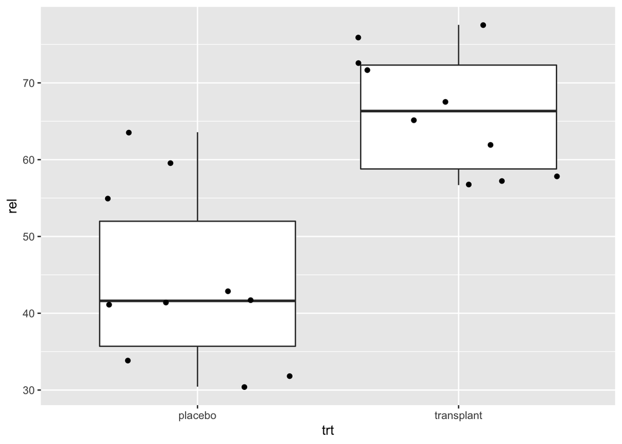

```r
ap %>%  ggplot(aes(x=trt,y=rel)) + geom_boxplot(outlier.shape=NA) + geom_point(position="jitter")
```

## 1.3 Some concepts

- Why do we need more than one student per group?
- What are the meaning and the consequences of the term “randomly”?
- Consider two designs:
1. A research assistant selects 20 male students from his faculty with smelly armpits
2. A research assistant selects 20 random people with smelly armpits from the Belgian population.

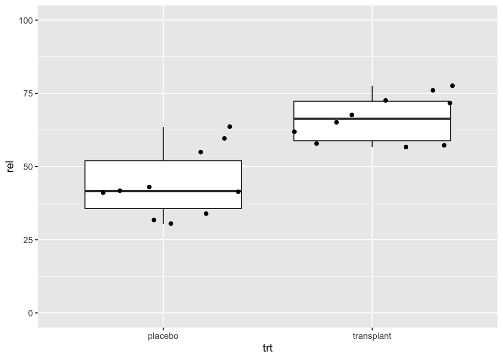

```r
ap %>%  ggplot(aes(x=trt,y=rel)) + geom_boxplot(outlier.shape=NA) + geom_point(position="jitter") + ylim(0,100)
```

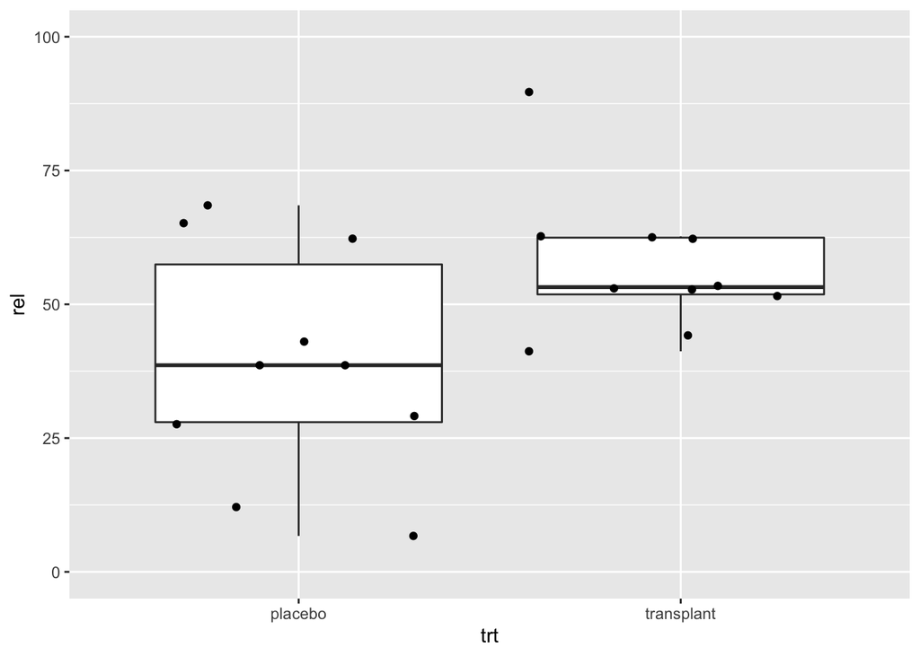

```r
ap2 %>%  ggplot(aes(x=trt,y=rel)) + geom_boxplot(outlier.shape=NA) + geom_point(position="jitter") + ylim(0,100)
```

- Design 1: smaller variability
- Design 2: larger variability and lower relative abundance of *Staphylococcus*
- What is the best design?
- Random sampling is closely related to the concept of the population or the scope of the study.
- Based on a sample of subjects, the researchers want to come to conclusions that hold for
  - all kind of people
  - only male students
- Scope of the study should be well specified before the start of the study.
- For the statistical analysis to be valid, it is required that the subjects are selected completely at random from the population to which we want to generalize our conclusions.
- Selecting completely at random from a population implies:
  - all subjects in the population should have the same probability of being selected in the sample
  - the selection of a subject in the sample should be independent from the selection of the other subjects in the sample.
  - The sample is thus supposed to be representative for the population, but still it is random.
- What does this imply?

# 2 Sample to sample variability

National Health NHanes study

- Since 1999 approximately 5000 individuals of all ages are interviewed in their homes every year
- The health examination component of the survey is conducted in a mobile examination centre (MEC).
- We will use this large study to select random subjects from the American population.
- This will help us to understand how the results of an analysis and the conclusions vary from sample to sample.

```r
library(NHANES)
head(NHANES)
```

```
# A tibble: 6 x 76
     ID SurveyYr Gender   Age AgeDecade AgeMonths Race1 Race3 Education
  <int> <fct>    <fct>  <int> <fct>         <int> <fct> <fct> <fct>
1 51624 2009_10  male      34 " 30-39"        409 White <NA>  High Sch~
2 51624 2009_10  male      34 " 30-39"        409 White <NA>  High Sch~
3 51624 2009_10  male      34 " 30-39"        409 White <NA>  High Sch~
4 51625 2009_10  male       4 " 0-9"           49 Other <NA>  <NA>
5 51630 2009_10  female    49 " 40-49"        596 White <NA>  Some Col~
6 51638 2009_10  male       9 " 0-9"          115 White <NA>  <NA>
# ... with 67 more variables: MaritalStatus <fct>, HHIncome <fct>,
#   HHIncomeMid <int>, Poverty <dbl>, HomeRooms <int>, HomeOwn <fct>,
#   Work <fct>, Weight <dbl>, Length <dbl>, HeadCirc <dbl>, Height <dbl>,
#   BMI <dbl>, BMICatUnder20yrs <fct>, BMI_WHO <fct>, Pulse <int>,
#   BPSysAve <int>, BPDiaAve <int>, BPSys1 <int>, BPDia1 <int>,
#   BPSys2 <int>, BPDia2 <int>, BPSys3 <int>, BPDia3 <int>,
#   Testosterone <dbl>, DirectChol <dbl>, TotChol <dbl>, UrineVol1 <int>,
#   UrineFlow1 <dbl>, UrineVol2 <int>, UrineFlow2 <dbl>, Diabetes <fct>,
#   DiabetesAge <int>, HealthGen <fct>, DaysPhysHlthBad <int>,
#   DaysMentHlthBad <int>, LittleInterest <fct>, Depressed <fct>,
#   nPregnancies <int>, nBabies <int>, Age1stBaby <int>,
#   SleepHrsNight <int>, SleepTrouble <fct>, PhysActive <fct>,
#   PhysActiveDays <int>, TVHrsDay <fct>, CompHrsDay <fct>,
#   TVHrsDayChild <int>, CompHrsDayChild <int>, Alcohol12PlusYr <fct>,
#   AlcoholDay <int>, AlcoholYear <int>, SmokeNow <fct>, Smoke100 <fct>,
#   Smoke100n <fct>, SmokeAge <int>, Marijuana <fct>, AgeFirstMarij <int>,
#   RegularMarij <fct>, AgeRegMarij <int>, HardDrugs <fct>, SexEver <fct>,
#   SexAge <int>, SexNumPartnLife <int>, SexNumPartYear <int>,
#   SameSex <fct>, SexOrientation <fct>, PregnantNow <fct>
```

```r
glimpse(NHANES)
```

```
Observations: 10,000
Variables: 76
$ ID               <int> 51624, 51624, 51624, 51625, 51630, 51638, 516...
$ SurveyYr         <fct> 2009_10, 2009_10, 2009_10, 2009_10, 2009_10, ...
$ Gender           <fct> male, male, male, male, female, male, male, f...
$ Age              <int> 34, 34, 34, 4, 49, 9, 8, 45, 45, 45, 66, 58, ...
$ AgeDecade        <fct>  30-39,  30-39,  30-39,  0-9,  40-49,  0-9,  ...
$ AgeMonths        <int> 409, 409, 409, 49, 596, 115, 101, 541, 541, 5...
$ Race1            <fct> White, White, White, Other, White, White, Whi...
$ Race3            <fct> NA, NA, NA, NA, NA, NA, NA, NA, NA, NA, NA, N...
$ Education        <fct> High School, High School, High School, NA, So...
$ MaritalStatus    <fct> Married, Married, Married, NA, LivePartner, N...
$ HHIncome         <fct> 25000-34999, 25000-34999, 25000-34999, 20000-...
$ HHIncomeMid      <int> 30000, 30000, 30000, 22500, 40000, 87500, 600...
$ Poverty          <dbl> 1.36, 1.36, 1.36, 1.07, 1.91, 1.84, 2.33, 5.0...
```

[output cut: 63 more lines]

Suppose that we are interested in assessing the difference in direct cholestorol levels between males and females older than 25 years.

## 2.1 Data exploration

1. We filter the data according to age.
2. We plot the direct cholestorol levels.
   - We select the data with the command `ggplot(aes(x=DirectChol))`
   - We add a histogram with the command `geom_histogram()`
   - We make to vertical panels using the command `facet_grid(Gender~.)`
   - We customize the label of the x-axis with the `xlab` command.

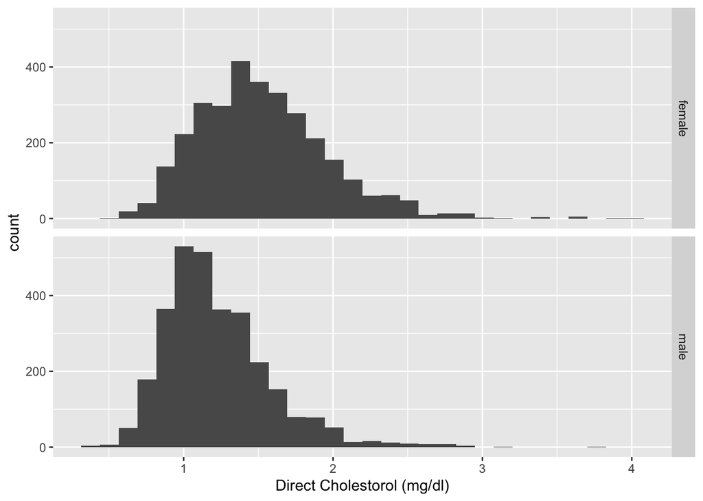

```r
NHANES%>%filter(NHANES$Age>25)%>%
  ggplot(aes(x=DirectChol))+
  geom_histogram() +
  facet_grid(Gender~.) +
  xlab("Direct Cholestorol (mg/dl)")
```

- Cholestorol levels and concentration measurements are often skewed.
- They cannot be lower than 0.
- They are often log transformed.

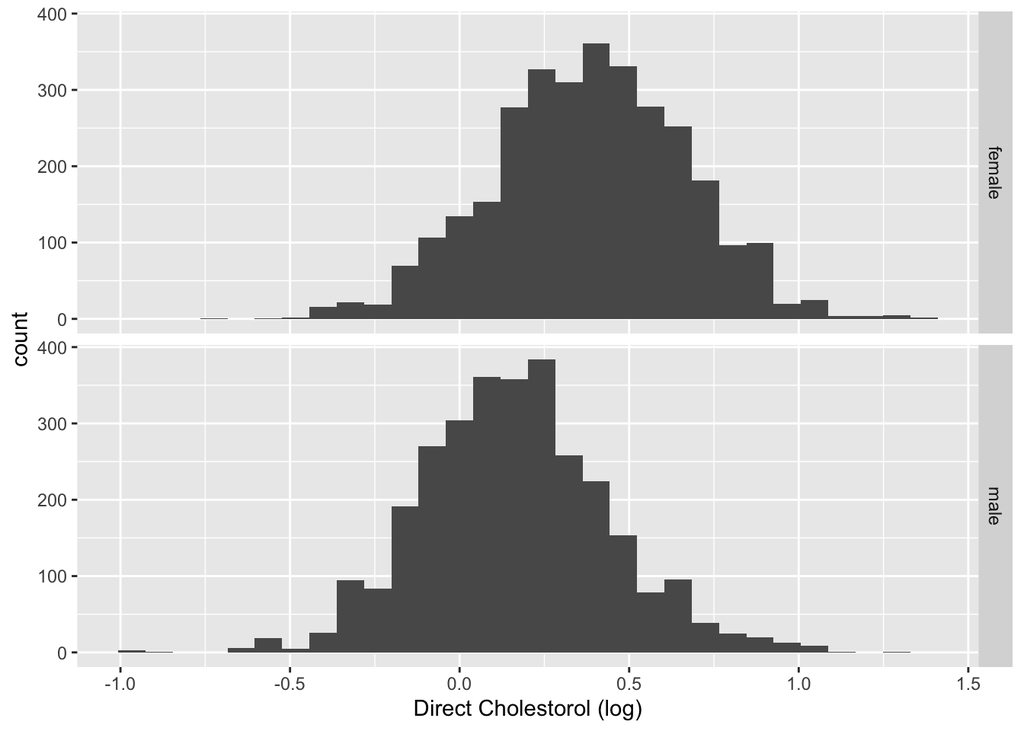

```r
NHANES%>%filter(NHANES$Age>25)%>%
  ggplot(aes(x=DirectChol%>%log))+
  geom_histogram() +
  facet_grid(Gender~.) +
  xlab("Direct Cholestorol (log)")
```

We see that the data are more or less bell shaped upon log transformation.

We will now create a subset of the data that we will use to sample from in the next sections.

1. We filter on age and remove subjects with missing values (NA).
2. We only select the variables Gender and DirectChol from the dataset to avoid unnessary variabeles
3. With the mutate function we can add a new variable logChol with log transformed direct cholestorol levels.

```r
nhanesSub<- NHANES%>%filter(Age>25&!is.na(DirectChol)) %>% select(c("Gender","DirectChol")) %>% mutate(cholLog=log(DirectChol))

Rmisc::summarySE(measurevar = "cholLog","Gender",data=nhanesSub)
```

```
  Gender    N   cholLog        sd          se          ci
1 female 3099 0.3832368 0.2826532 0.005077420 0.009955449
2   male 3025 0.1647580 0.2769783 0.005035969 0.009874271
```

## 2.2 Experiment

- Suppose that we would have no access to cholestorol levels of the American population.
- Then, we would have to setup an experiment.
- Suppose that we have a budget for assessing 10 females and 10 males
- We will subset 10 females and 10 males at random from the American population and measure their direct cholestorol levels.

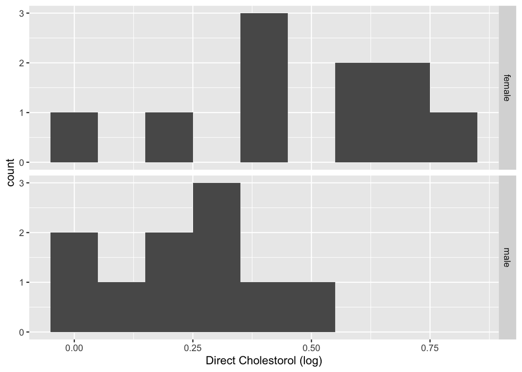

```r
fem<-nhanesSub%>%filter(Gender=="female")%>%sample_n(size=10)
mal<-nhanesSub%>%filter(Gender=="male")%>%sample_n(size=10)

samp<-rbind(fem,mal)

samp%>%
  ggplot(aes(x=DirectChol%>%log))+
  geom_histogram(binwidth = .1) +
  facet_grid(Gender~.) +
  xlab("Direct Cholestorol (log)")
```

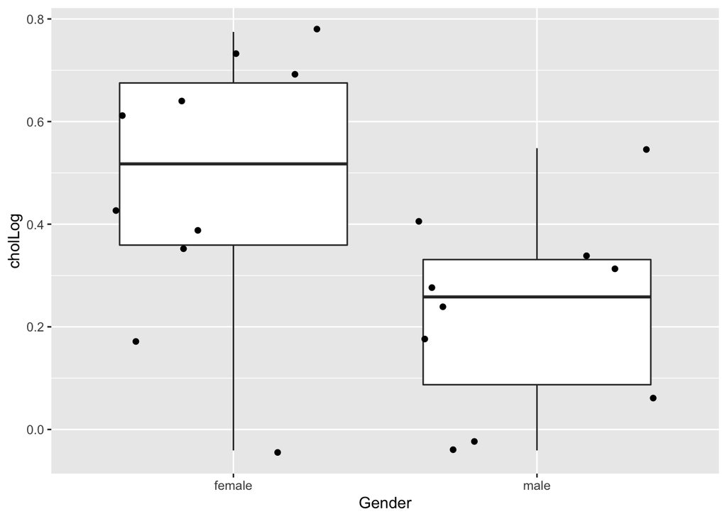

```r
samp%>% ggplot(aes(x=Gender,y=cholLog)) + geom_boxplot(outlier.shape=NA) + geom_point(position="jitter")
```

```r
Rmisc::summarySE(measurevar = "cholLog","Gender",data=samp)
```

```
  Gender  N   cholLog        sd         se        ci
1 female 10 0.4740687 0.2647728 0.08372851 0.1894070
2   male 10 0.2292716 0.1889862 0.05976268 0.1351926
```

```r
t.test(cholLog~Gender,samp,var.equal=TRUE)
```

```
    Two Sample t-test

data:  cholLog by Gender
t = 2.3797, df = 18, p-value = 0.02859
alternative hypothesis: true difference in means is not equal to 0
95 percent confidence interval:
 0.02867725 0.46091694
sample estimates:
mean in group female   mean in group male
           0.4740687            0.2292716
```

## 2.3 Repeat the experiment

If we would do the experiment again we would select other people and we will obtain different results.

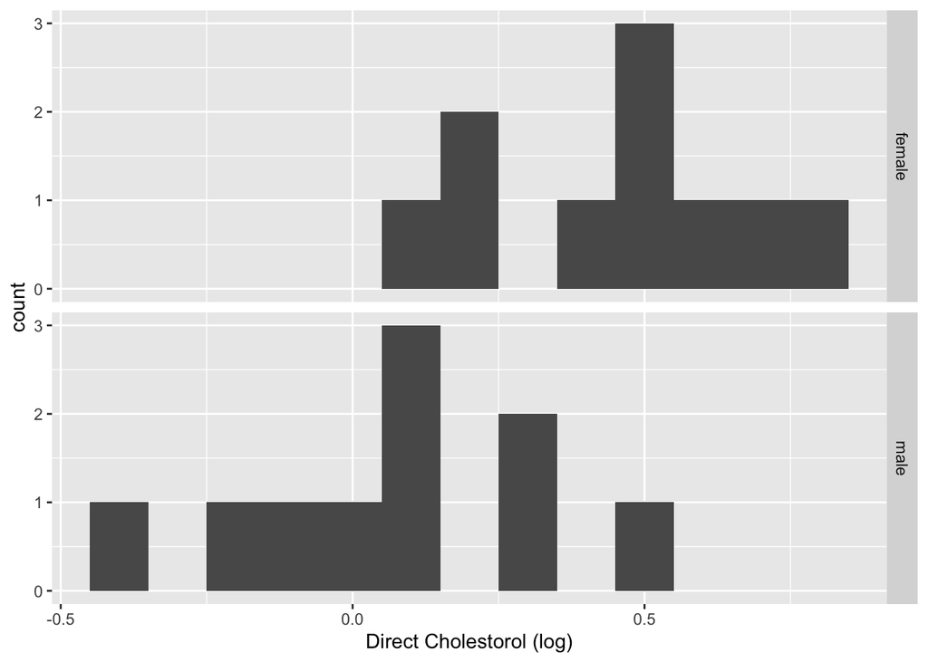

```r
fem<-nhanesSub%>%filter(Gender=="female")%>%sample_n(size=10)
mal<-nhanesSub%>%filter(Gender=="male")%>%sample_n(size=10)

samp2<-rbind(fem,mal)
samp2%>%ggplot(aes(x=DirectChol%>%log))+
  geom_histogram(binwidth = .1) +
  facet_grid(Gender~.) +
  xlab("Direct Cholestorol (log)")
```

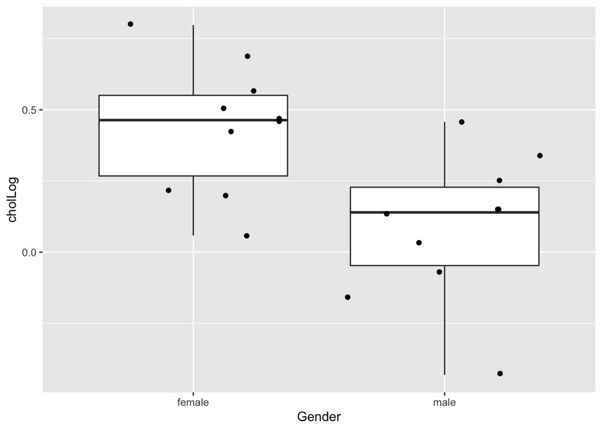

```r
samp2%>% ggplot(aes(x=Gender,y=cholLog)) + geom_boxplot(outlier.shape=NA) + geom_point(position="jitter")
```

```r
Rmisc::summarySE(measurevar = "cholLog","Gender",data=samp2)
```

```
  Gender  N    cholLog        sd         se        ci
1 female 10 0.43827006 0.2273978 0.07190949 0.1626706
2   male 10 0.08400938 0.2573519 0.08138181 0.1840984
```

```r
t.test(cholLog~Gender,samp2,var.equal=TRUE)
```

```
    Two Sample t-test

data:  cholLog by Gender
t = 3.2621, df = 18, p-value = 0.004329
alternative hypothesis: true difference in means is not equal to 0
95 percent confidence interval:
 0.1261004 0.5824209
sample estimates:
mean in group female   mean in group male
          0.43827006           0.08400938
```

## 2.4 And again

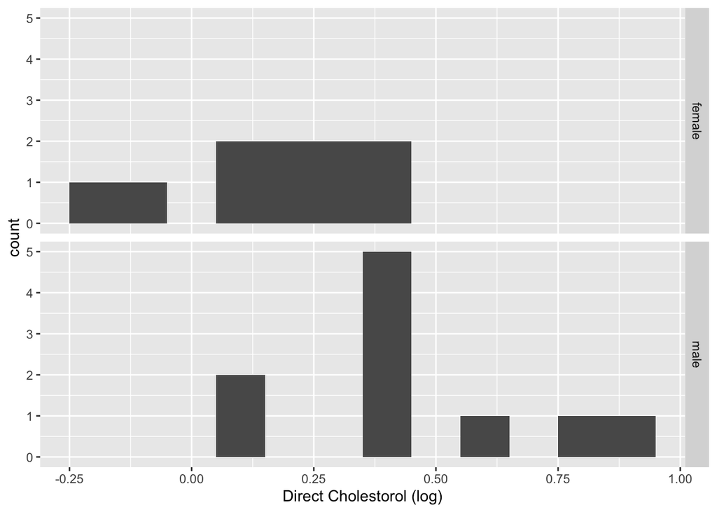

```r
set.seed(12857)
fem<-nhanesSub%>%filter(Gender=="female")%>%sample_n(size=10)
mal<-nhanesSub%>%filter(Gender=="male")%>%sample_n(size=10)

samp2<-rbind(fem,mal)
samp2%>%ggplot(aes(x=DirectChol%>%log))+
  geom_histogram(binwidth = .1) +
  facet_grid(Gender~.) +
  xlab("Direct Cholestorol (log)")
```

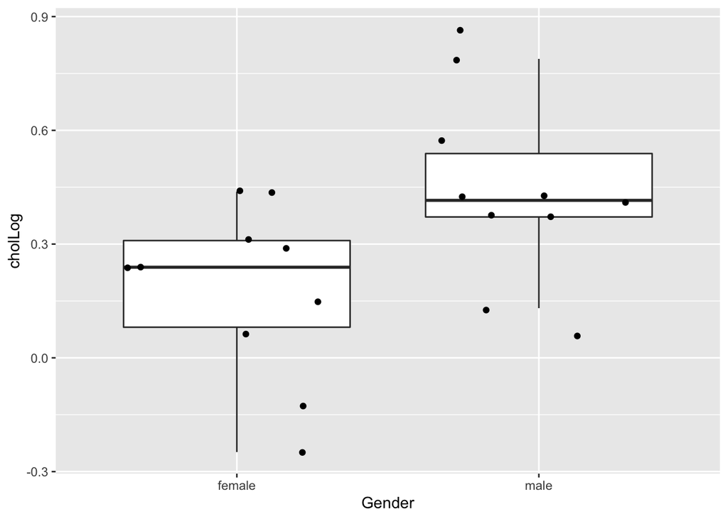

```r
samp2%>% ggplot(aes(x=Gender,y=cholLog)) + geom_boxplot(outlier.shape=NA) + geom_point(position="jitter")
```

```r
Rmisc::summarySE(measurevar = "cholLog","Gender",data=samp2)
```

```
  Gender  N   cholLog        sd         se        ci
1 female 10 0.1792418 0.2273949 0.07190859 0.1626685
2   male 10 0.4420596 0.2526821 0.07990509 0.1807579
```

```r
t.test(cholLog~Gender,samp2,var.equal=TRUE)
```

```
    Two Sample t-test

data:  cholLog by Gender
t = -2.4449, df = 18, p-value = 0.02501
alternative hypothesis: true difference in means is not equal to 0
95 percent confidence interval:
 -0.48866123 -0.03697434
sample estimates:
mean in group female   mean in group male
           0.1792418            0.4420596
```

## 2.5 Summary

```r
set.seed(1)
nsim<-20000
nSamp<-10
res<-matrix(0,nrow=nsim,ncol=2)
fem<-nhanesSub%>%filter(Gender=="female")
mal<-nhanesSub%>%filter(Gender=="male")

for (i in 1:nsim)
{
 femSamp<-sample(fem$cholLog,nSamp)
 malSamp<-sample(mal$cholLog,nSamp)

meanFem<-mean(femSamp)
 meanMal<-mean(malSamp)
 delta<-meanFem-meanMal
 sdFem<-sd(femSamp)
 sdMal<-sd(malSamp)
 seFem<-sdFem/sqrt(nSamp)
 seFem<-sdFem/sqrt(nSamp)
 sdPool<-sqrt((sdFem^2*(nSamp-1) + sdMal^2*(nSamp-1))/(2*nSamp-2))
tvalue<-(delta)/(sdPool*sqrt(1/nSamp+1/nSamp))
pvalue<-pt(abs(tvalue),lower.tail = FALSE,df=2*nSamp-2)*2
 res[i,]<-c(delta,pvalue)
}
sum(res[,2]<0.05&res[,1]>0)
```

```
[1] 7680
```

```r
sum(res[,2]>0.05)
```

```
[1] 12319
```

```r
sum(res[,2]<0.05&res[,1]<0)
```

```
[1] 1
```

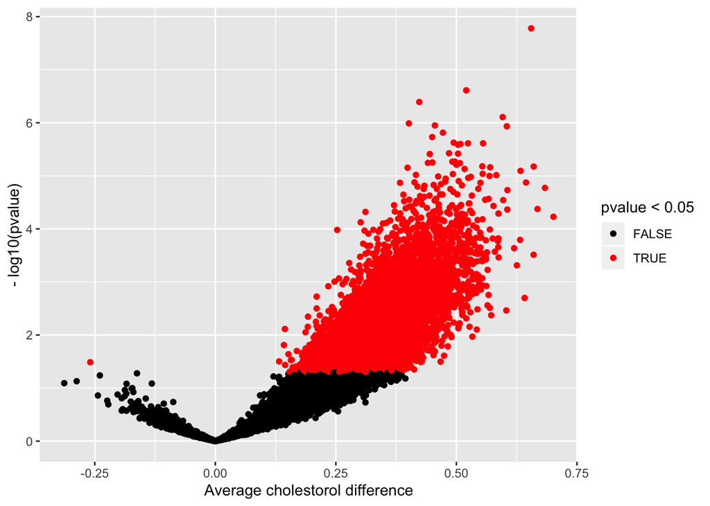

```r
res<-res %>% as.data.frame
names(res) <- c("delta","pvalue")
res %>% ggplot(aes(x=delta,y=-log10(pvalue),color=pvalue<0.05)) + geom_point() + xlab("Average cholestorol difference") + ylab("- log10(pvalue)") + scale_color_manual(values=c("black","red"))
```

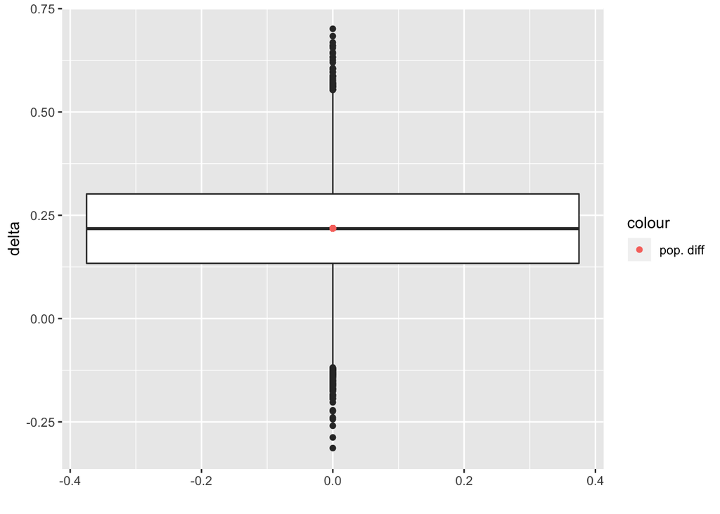

```r
res %>% ggplot(aes(y=delta)) +geom_boxplot() + geom_point(aes(x=0,y=c(mean(fem$cholLog)-mean(mal$cholLog)),color="pop. diff")) +xlab("")
```

## 2.6 Assignment

1. Copy the code chunk with the simulation study
2. Add it here below
3. Modify the sample size to 50.
4. What do you observe?

# 3 Salk study

- In 1916 first large polio epidemy in the US
- John Salk developed a vaccine with promising results in the lab in the early fifties
- In 1954 the National Foundation for Infantile Paralysis (NFIP) has setup a large study to assess the effectiveness of the Salk vaccine.
- Suppose that the NFIP would have vaccinated a large number of childeren in 1954 and would have observed that the polio incidence in 1954 was lower than in 1953. Could they have concluded that the vaccine was effective?

## 3.1 NFIP study

### 3.1.2 Data

```r
nfip<-data.frame(group=c("cases","control","noConcent"),grade=c("g2","g1g3","g2"),vaccin=c("yes","no","no"),total=c(221998,725173,123605),polio=c(54,391,56))
nfip$noPolio<-nfip$total-nfip$polio
knitr::kable(nfip)
```

| group | grade | vaccin | total | polio | noPolio |
| --- | --- | --- | --- | --- | --- |
| cases | g2 | yes | 221998 | 54 | 221944 |
| control | g1g3 | no | 725173 | 391 | 724782 |
| noConcent | g2 | no | 123605 | 56 | 123549 |

Compare polio incidence?

What can we conclude?

## 3.2 Confounding

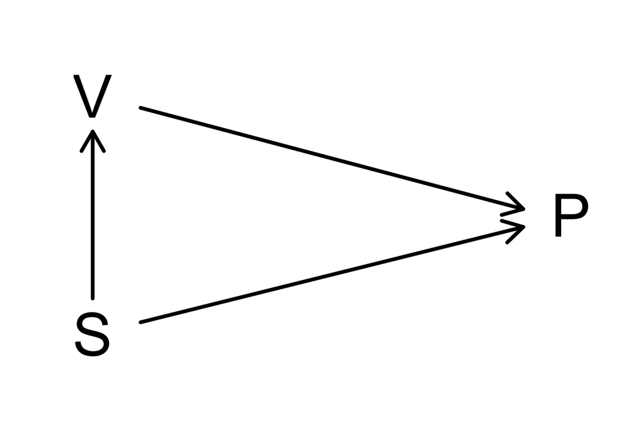

- We observe a lower polio (P) incidence for children for who no consent was given than for the children in the control group
- Consent for vaccination (V) was associated with the socio-economic status (S)
- Children of lower socio-economic status were more resistant to the disease.
- The groups of cases and controls are not comparable:
  - Difference in age
  - Difference in socio-economic status
  - Difference in susceptible for disease

## 3.3 Salk Study

### 3.3.1 Design

A new study was conducted: Randomized double blind study

- Children are assigned at random to the control or case treatment arm after consent was given by the parents
- Control: vaccination with placebo
- Treatment: vaccination with vaccine
- double blinding:
  - parents did not know if their child was vaccinated or received the placebo
  - care-giver/researchers did not know if the child was vaccinated or recieved placebo

### 3.3.2 Data

```r
salk<-data.frame(group=c("cases","control","noConcent"),treatment=c("vaccine","placebo","none"),total=c(200745,
201229, 338778),polio=c(57,142,157))
salk$noPolio<-salk$total-salk$polio
salk$incidencePM<-round(salk$polio/salk$total*1e6,0)
knitr::kable(salk)
```

| group | treatment | total | polio | noPolio | incidencePM |
| --- | --- | --- | --- | --- | --- |
| cases | vaccine | 200745 | 57 | 200688 | 284 |
| control | placebo | 201229 | 142 | 201087 | 706 |
| noConcent | none | 338778 | 157 | 338621 | 463 |

# 4 Scientific method

- Empirical data is key in the life sciences.
- Research is largely driven by data.

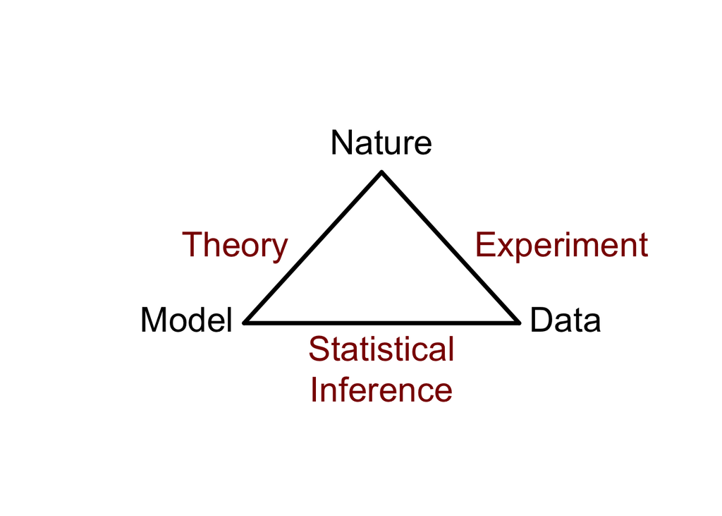

- *Nature*: biological process which we study
- *Deduction*: Deduce logical consequences of the theory/hypothesis that can be experimentally validated
- *Experiment*: collect data on the process. The data are a manifestation of the real process. The experiment has to be *representative* and *reproducible* and should challenge the theory. *Experimental Design*!
- *Statistical inference*: Bridge to confront the model/hypothesis to the data $\rightarrow$ Cornerstone of the scientific method.
- *Falsification principle*: Data cannot be used to prove a model/hypothesis, only to reject it.
- *Data-exploration and analysis* is typically used to refine the theory and to generate new hypotheses.

# 5 Role of Statistics in the life sciences

- We have seen that
  - it is important to carefully specify the scope of the study before the experiment.
  - the sample size matters
  - we should be aware of confounding
  - a proper control is required.

$\rightarrow$ Good experimental design is crucial!

- We also observed that there is variability in the population and because we can only sample a small part of the population our results and conclusions are subjected to uncertainty.
- Statistics is the science on
  1. collecting (experimental design),
  2. exploring (data exploration) and
  3. learning from data and to generalize what we observe in the sample towards the population while quantifying, controlling and reporting variability and uncertainty (statistical modelling and statistical inference).
- Therefore, statistics plays an important role in almost all sciences (e.g. column “points of significance” in Nature Methods. http://blogs.nature.com/methagora/2013/08/giving_ statistics_the_attention_it_deserves.html)